# Umbria

- Mostra il codice
- Nascondere il codice
- Vedere il codice

Principali indicatori demografici

Autore/Autrice

Affiliazione

Lorenzo Mattioli

Alma Mater Studiorum - Università di Bologna

Data di Pubblicazione

5 dicembre 2024

Exam paper written for an international demography course at the Alma Mater Studiorum - University of Bologna (prof. Rosella Rettaroli). As the exam was held in Italian, the following text is written in the same language.

*Umbria is a moderate-sized region in central Italy. On 1 January 2019, the Umbria population was 882,015. Of these, 13.8% were at least 75 years old (ISTAT 2019). Made famous by its natural, artistic and cultural heritage, as well as by its curious status as the only region in central Italy not to have any sea frontage, Umbria is a perfect case study for demography. The evolution of the age structure of the Umbrian population anticipated in a certain way the dynamics that later characterised the entire Italian population.*

Check out my quarto presentation on the topic

# Introduzione

L’Umbria è una regione di dimensioni moderate del Centro Italia. Al 1° gennaio 2019, la popolazione umbra ammontava a 882.015 residenti. Di questi, il 13,8% aveva almeno 75 anni (ISTAT 2019). Secondo le ultime previsioni Istat, la popolazione umbra seguirà una decisa parabola discendente mano a mano che ci si avvicinerà al 2050.

Resa celebre dal proprio patrimonio naturalistico, artistico e culturale, nonché per la curiosa condizione di unica regione dell’Italia centrale a non avere alcun affaccio sul mare, l’Umbria è un perfetto caso di studio per la demografia. L’evoluzione della struttura per età della popolazione umbra ha anticipato in un certo qual modo le dinamiche che hanno poi caratterizzato quella italiana nella sua interezza.

**Codice**

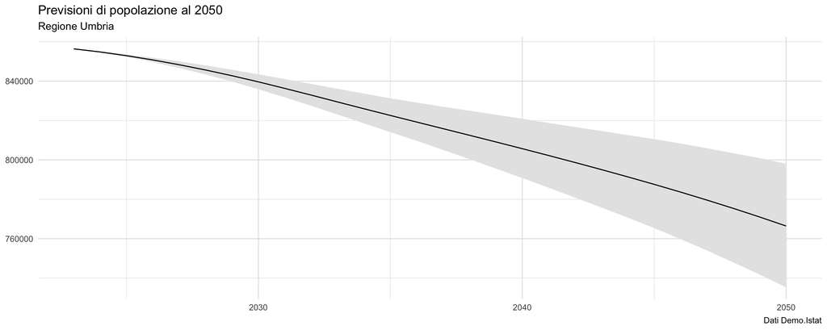

```r
umPrev |>
  ggplot(aes(x = Anno)) +
  geom_ribbon(aes(ymin = `Limite inferiore intervallo di confidenza al 90% (5° percentile)`,
                  ymax = `Limite superiore intervallo di confidenza al 90% (95° percentile)`), fill = 'gray90') +
  geom_line(aes(y = `Scenario mediano`), linetype = 1) +
  labs(title = 'Previsioni di popolazione al 2050',
       subtitle = 'Regione Umbria',
       caption = 'Dati Demo.Istat') +
  theme(legend.position = 'bottom',
        panel.background = element_blank(),
        panel.grid = element_line(colour = 'gray90'),
        legend.title = element_blank(),
        axis.ticks = element_blank(),
        axis.title = element_blank())
```

Un fattore da tenere a mente è che le dinamiche di popolazione che in questo documento sono considerate a livello regionale sono in realtà valori medi di una situazione fortemente diseguale. Un diffuso fenomeno di abbandono e migrazione interna del (pede-)montano e delle campagne da parte delle fasce giovani della popolazione ha comportato negli ultimi anni la concentrazione degli individui più anziani nelle aree rurali.

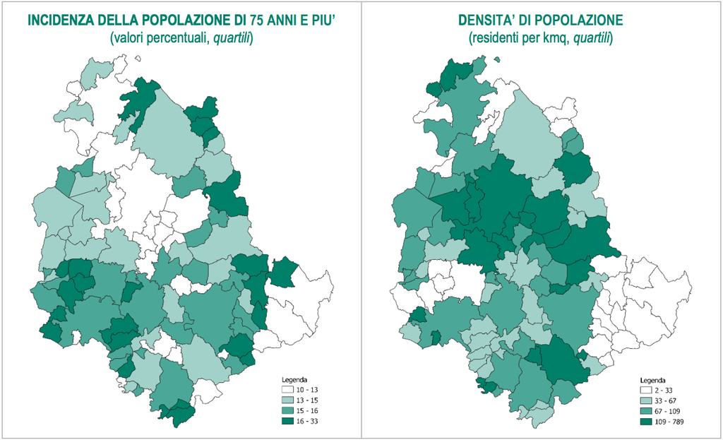

Fonte: ISTAT, Rilevazione sulla popolazione residente comunale per sesso, anno di nascita e stato civile; Istat, Confini delle unità amministrative e basi territoriali

Nei successivi paragrafi, la popolazione umbra verrà messa sotto il microscopio. Dopo una prima analisi descrittiva della struttura per età, verranno presi in esame i principali indicatori riguardo migrazione, fecondità e mortalità. Allo scopo di ottenere una maggiore profondità di indagine, verranno calcolati anche indici specifici per età e gruppi sociali (cittadini italiani e stranieri). I dati utilizzati sono estratti da («Demo - Statistiche demografiche», s.d.).

# Analisi della struttura per età

## Piramidi delle età

L’Umbria è una regione particolarmente anziana. Nel 2000 presentava, infatti, delle proporzioni di popolazione oltre ai 65 anni decisamente maggiori rispetto a quelle riscontrabili nell’interezza della popolazione italiana. Al 2024, la composizione per età della popolazione umbra ricalca più fedelmente quella nazionale. La forma della piramide risulta però sempre lievemente più spostata verso le età molto avanzate, a suggerire una sopravvivenza degli individui della terza età più elevata rispetto alla media nazionale.

**Codice**

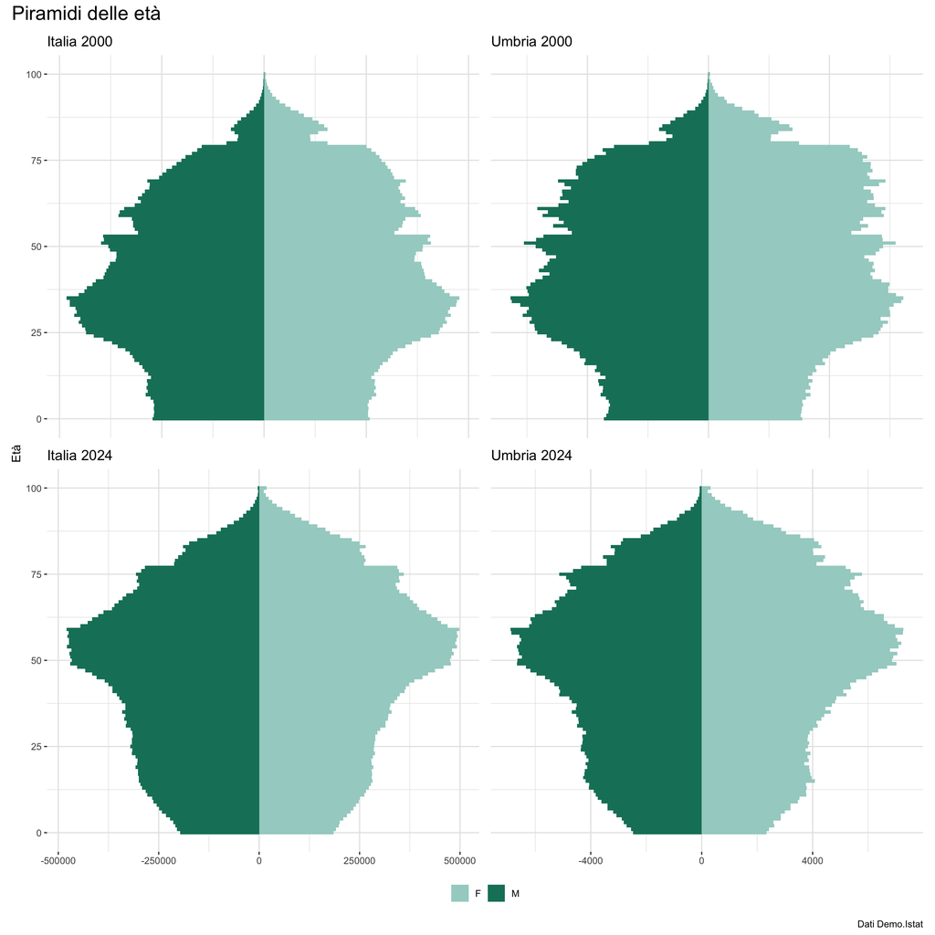

```r
## Italia ----
### 2024
it24gg <- it24 |>
  filter(Sesso != 'Totale') |>
  ggplot(aes(x = Età,
             y = ifelse(Sesso == 'M',
                        -`Tot per genere`, `Tot per genere`),
             fill = Sesso)) +
  geom_bar(stat = 'identity', width = 1) +
  coord_flip() +
  scale_fill_manual(values = c('#A4D1CA', '#148068')) +
  labs(title = 'Italia 2024')

it00gg <- it00 |>
  filter(Sesso != 'Totale') |>
  ggplot(aes(x = Età,
             y = ifelse(Sesso == 'M',
                        -`2000`, `2000`),
             fill = Sesso)) +
  geom_bar(stat = 'identity', width = 1) +
  coord_flip() +
  scale_fill_manual(values = c('#A4D1CA', '#148068')) +
  labs(title = 'Italia 2000')

## Umbria ----
### 2024
um24gg <- um24 |>
  filter(Sesso != 'Totale') |>
  ggplot(aes(x = Età,
             y = ifelse(Sesso == 'M',
                        -`Tot per genere`, `Tot per genere`),
             fill = Sesso)) +
  geom_bar(stat = 'identity', width = 1) +
  coord_flip() +
  scale_fill_manual(values = c('#A4D1CA', '#148068')) +
  labs(title = 'Umbria 2024')

um00gg <- um00 |>
  filter(Sesso != 'Totale') |>
  ggplot(aes(x = Età,
             y = ifelse(Sesso == 'M',
                        -`2000`, `2000`),
             fill = Sesso)) +
  geom_bar(stat = 'identity', width = 1) +
  coord_flip() +
  scale_fill_manual(values = c('#A4D1CA', '#148068')) +
  labs(title = 'Umbria 2000')

## Patchwork ----
it00gg + um00gg + it24gg + um24gg +
  plot_layout(guides = 'collect', axes = 'collect') +
  plot_annotation(title = 'Piramidi delle età',
                  caption = 'Dati Demo.Istat',
                  theme = theme(plot.title = element_text(size = 18))) &
  theme(legend.position = 'bottom',
        axis.title.x = element_blank(),
        # axis.text.x = element_blank(),
        # axis.ticks.x = element_blank(),
        panel.background = element_blank(),
        panel.grid = element_line(colour = 'gray90'),
        legend.title = element_blank(),
        plot.title.position = 'panel')
```

## Indici di popolazione

La particolare anzianità della popolazione umbra si riscontra immediatamente confrontando l’età media regionale con quella dell’Italia intera nell’ultimo venticinquennio: anche a netto di una tendenza generalizzata all’invecchiamento, la differenza tra il valore regionale e la media nazionale rimane sempre positiva. Notevole è però il fatto che l’Umbria sia nell’atto di essere *raggiunta* dal resto del Paese, con una diminuzione della distanza tra i due valori medi totali da 2,78 a 1,55 anni. Si noti che l’età media della popolazione femminile è sempre maggiore di quella maschile. Questo è principalmente dovuto a una maggiore sopravvivenza femminile in età avanzata, come riscontrabile analizzando le piramidi delle età di cui sopra.

**Codice**

```r
girafe(ggobj = etadf |>
  mutate(Anno = anno,
         'Territorio' = geo,
         'Femmine' = round(etaMed_F, 2),
         'Maschi' = round(etaMed_M, 2),
         'Totale' = round(etaMed_Totale, 2),
         'Giovanile' = round(dipGiov, 2),
         'Vecchiaia' = round(dipVec, 2),
         'Complessivo' = round(dip, 2),
         'Indice di vecchiaia' = round(vec, 2),
         'Rapporto di mascolinità' = round(rapMasc, 2)
         ) |>
  select(Anno, Territorio, Femmine, Maschi, Totale) |>
  pivot_longer(cols = c(Femmine, Maschi, Totale)) |>
  ggplot(aes(x = name, y = value, fill = factor(Anno), dataid = value, tooltip = value)) +
  geom_col_interactive(position = 'dodge', width = .6) +
  geom_hline(yintercept = 0) +
  geom_text(aes(y = 2, label = name), hjust = 0, col = 'white') +
  coord_flip() +
  labs(title = 'Età medie',
       caption = 'Dati Demo.Istat') +
  scale_fill_manual(values = c('#A4D1CA', '#148068')) +
  scale_y_continuous(expand = c(0, 0)) +
  facet_wrap(~Territorio) +
  theme(legend.position = 'bottom',
        axis.title = element_blank(),
        axis.text.y = element_blank(),
        axis.ticks.y = element_blank(),
        panel.background = element_blank(),
        panel.grid = element_line(colour = 'gray90'),
        legend.title = element_blank(),
        strip.background = element_blank(),
        plot.title.position = 'panel',
        panel.grid.major.x = element_line(color = "#A8BAC4", size = 0.3)),
  options = list(
         opts_tooltip(css = 'background-color:white;
                      color:black;
                      font-family:Helvetica;
                      font-style:empty;
                      padding:8px;
                      border-radius:10px;
                      background:rgba(255, 255, 255, 0.8);'),
         opts_hover(css = ''),
         opts_hover_inv(css = "opacity:0.3;"),
         opts_toolbar(hidden = c('selection', 'zoom', 'misc'))))
```

[interactive chart not shown]

La composizione per età dell’Umbria ha anche un effetto tangibile sugli indici di dipendenza: se quello giovanile è più basso sia nel 2000 che nel 2024, quello di vecchiaia è sempre superiore all’indice calcolato sulla popolazione nazionale. L’inclemente risultato è quello di un indice di dipendenza complessivo sempre superiore alla media nazionale, con un potenziale effetto deleterio sul tessuto produttivo regionale. L’indice di vecchiaia mostra in maniera ancora più drammatica lo squilibrio tra la popolazione anziana e quella in età pre-lavorativa.

**Codice**

```r
girafe(ggobj = etadf |>
  mutate(Anno = anno,
         'Territorio' = geo,
         'Femmine' = round(etaMed_F, 2),
         'Maschi' = round(etaMed_M, 2),
         'Totale' = round(etaMed_Totale, 2),
         'Giovanile' = round(dipGiov, 2),
         'Vecchiaia' = round(dipVec, 2),
         'Complessivo' = round(dip, 2),
         'Indice di vecchiaia' = round(vec, 2),
         'Rapporto di mascolinità' = round(rapMasc, 2)
         ) |>
  select(Anno, Territorio, Giovanile, Vecchiaia, Complessivo) |>
  pivot_longer(cols = c(Giovanile, Vecchiaia, Complessivo)) |>
  ggplot(aes(x = name, y = value, fill = factor(Anno), dataid = value, tooltip = value)) +
  geom_col_interactive(position = 'dodge', width = .6) +
  geom_hline(yintercept = 0) +
  geom_text(aes(y = .02, label = name), hjust = 0, col = 'white') +
  coord_flip() +
  labs(title = 'Indici di indipendenza',
       caption = 'Dati Demo.Istat') +
  scale_fill_manual(values = c('#A4D1CA', '#148068')) +
  scale_y_continuous(expand = c(0, 0)) +
  facet_wrap(~Territorio) +
  theme(legend.position = 'bottom',
        axis.title = element_blank(),
        axis.text.y = element_blank(),
        axis.ticks.y = element_blank(),
        panel.background = element_blank(),
        panel.grid = element_line(colour = 'gray90'),
        legend.title = element_blank(),
        strip.background = element_blank(),
        plot.title.position = 'panel',
        panel.grid.major.x = element_line(color = "#A8BAC4", size = 0.3)),
  options = list(
         opts_tooltip(css = 'background-color:white;
                      color:black;
                      font-family:Helvetica;
                      font-style:empty;
                      padding:8px;
                      border-radius:10px;
                      background:rgba(255, 255, 255, 0.8);'),
         opts_hover(css = ''),
         opts_hover_inv(css = "opacity:0.3;"),
         opts_toolbar(hidden = c('selection', 'zoom', 'misc'))))
```

[interactive chart not shown]

Alcune ultime considerazioni riguardano il rapporto di mascolinità. Sia quando calcolato sull’intera popolazione italiana, sia quando ristretto solamente alla regione Umbria, questo indicatore presenta uno squilibrio verso i maschi ad età zero ed uno verso le femmine nella popolazione totale. Questo significa che se è vero che nascono più uomini che donne, è anche vero che i primi tendono ad essere eliminati più facilmente dalla mortalità, portando il rapporto a pendere verso le seconde.

**Codice**

```r
etadf |>
  mutate(Anno = anno,
         'Territorio' = geo,
         'Femmine' = round(etaMed_F, 2),
         'Maschi' = round(etaMed_M, 2),
         'Totale' = round(etaMed_Totale, 2),
         'Giovanile' = round(dipGiov, 2),
         'Vecchiaia' = round(dipVec, 2),
         'Complessivo' = round(dip, 2),
         'Indice di vecchiaia' = round(vec, 2),
         'Popolazione' = round(rapMasc, 2),
         'Età 0' = round(rapMasc0, 2)
  ) |>
  select(Territorio, Femmine, Maschi, Totale, Giovanile, Vecchiaia, Complessivo, `Indice di vecchiaia`, `Popolazione`, `Età 0`) |>
  gt(rowname_col = 'Territorio') |>
  tab_stubhead(
    label = 'Anno'
  ) |>
  tab_row_group(
    label = '2000',
    rows = c(1,3)
  ) |>
  tab_row_group(
    label = '2024',
    rows = c(2,4)
  ) |>
  tab_header(
    title = md('## Indici di popolazione'),
    subtitle = md('Per **anno** e **territorio**')
  ) |>
  tab_spanner(
    label = 'Età media',
    columns = c(Femmine, Maschi, Totale)
  ) |>
  tab_spanner(
    label = 'Indice di dipendenza',
    columns = c(Giovanile, Vecchiaia, `Complessivo`)
  ) |>
  tab_spanner(
    label = 'Rapporto di mascolinità',
    columns = c(Popolazione, `Età 0`)
  ) |>
  tab_source_note(
    source_note = 'Dati Demo.Istat'
  ) |>
  cols_align(
    align = 'center',
    columns = 3:10
  ) |>
  cols_align(
    align = 'left',
    columns = 1:2
  ) |>
  tab_options(table.background.color = 'white',
              table.font.style = 'Roboto',
              table.border.top.color = 'white',
              heading.align = 'center',
              row.striping.include_stub =FALSE,
              heading.border.bottom.color = "white",
              row_group.border.bottom.color = "white",
              row_group.border.top.color = "white"
              )
```

Indici di popolazione

Per **anno** e **territorio**

Anno

Età media

Indice di dipendenza

Indice di vecchiaia

Rapporto di mascolinità

Femmine

Maschi

Totale

Giovanile

Vecchiaia

Complessivo

Popolazione

Età 0

2024

Italia

47.48

44.67

46.10

0.19

0.38

0.58

199.84

95.73

106.11

Umbria

49.08

46.13

47.65

0.18

0.44

0.62

237.93

93.94

105.51

2000

Italia

42.40

39.38

40.94

0.21

0.27

0.48

126.59

93.88

105.44

Umbria

45.16

42.18

43.72

0.19

0.34

0.53

182.31

93.59

111.89

Dati Demo.Istat

# Migrazioni

Il bilancio migratorio umbro durante i 22 anni fra il 2002 e il 2024 è generalmente positivo. Trainato da un incostante ma considerevole fenomeno immigratorio con l’estero, il saldo migratorio totale dell’Umbria è ulteriormente maggiorato da un saldo interno mediamente positivo fino al 2013. Fra il 2013 e il 2015, l’Umbria vive l’unico periodo emigratorio della sua storia recente, per poi registrare una generale tendenza al rialzo fino ad oggi.

## Saldi migratori

In generale, l’andamento del saldo migratorio umbro va di pari passo con quello nazionale, caratterizzato da due picchi nel 2003 (in corrispondenza dell’introduzione della legge Bossi-Fini) e nel 2007 (anno di ulteriori sanatorie, contemporanee all’entrata della Romania nell’Unione Europea). È interessante l’avvallamento del saldo migratorio totale fra il 2018 e il 2020, indipendente dal saldo migratorio interno e da quello con l’estero. Il motivo di questo disacoppiamento è con tutta probabilità dovuto a problemi definitori e di conteggio: Il saldo migratorio con l’estero non tiene conto di alcuni specifici fenomeni emigratori, su tutti i rimpatri. Nel 2018, per mezzo dei decreti sicurezza, c’è stato un notevole aumento di questo tipo di evento demografico, che potrebbe aver contribuito a causare il disaccoppiamento di cui sopra, rientrato solamente nel 2022.

**Codice**

```r
girafe(ggobj = inddf |>
  filter(var == 'Saldo migratorio con l\'estero' | var == 'Saldo migratorio interno' | var == 'Saldo migratorio') |>
  ggplot(aes(x = anno, y = value, dataid = anno, tooltip = value)) +
  geom_point_interactive(alpha = 0) +
  geom_line(data = ~. |> filter(Territorio == 'Italia' & var != 'Saldo migratorio interno')
            |> filter(var == 'Saldo migratorio'), aes(linetype = var)) +
  geom_line(data = ~. |> filter(Territorio == 'Italia' & var != 'Saldo migratorio interno')
            |> filter(var != 'Saldo migratorio'), aes(col = var)) +
  geom_line(data = ~. |> filter(Territorio == 'Umbria')
            |> filter(var == 'Saldo migratorio'), aes(linetype = var)) +
  geom_line(data = ~. |> filter(Territorio == 'Umbria')
            |> filter(var != 'Saldo migratorio'), aes(col = var)) +
  geom_line(data = ~. |> filter(var != 'Saldo migratorio'), aes(col = var)) +
  geom_hline(yintercept = 0, col = 'gray60') +
  scale_x_continuous(breaks = c(2002, 2004, 2006, 2008, 2010, 2012, 2014, 2016, 2018, 2020, 2022, 2024)) +
  scale_color_manual(values = c('#803014', '#148068')) +
  scale_linetype_manual(values = 'dashed') +
  labs(title = 'Saldi migratori',
       subtitle = 'Serie storica 2002-2023',
       caption = 'Dati Demo.Istat') +
  facet_wrap(~Territorio) +
  theme(legend.position = 'bottom',
        panel.background = element_blank(),
        panel.grid = element_line(colour = 'gray90'),
        legend.title = element_blank(),
        plot.title = element_text(size = 18),
        plot.subtitle = element_text(size = 12),
        strip.background = element_blank(),
        strip.text = element_text(size = 12),
        axis.ticks = element_blank(),
        axis.title = element_blank()),
  options = list(
         opts_tooltip(css = 'background-color:white;
                      color:black;
                      font-family:Helvetica;
                      font-style:empty;
                      padding:8px;
                      border-radius:10px;
                      background:rgba(255, 255, 255, 0.8);'),
         opts_hover(css = ''),
         opts_hover_inv(css = "opacity:0.3;"),
         opts_toolbar(hidden = c('selection', 'zoom', 'misc')))
  )
```

[interactive chart not shown]

# Fecondità

Il numero di figli per donna (tasso di fecondità totale, TFT) delle madri di nazionalità italiana in Umbria partiva nel 2002 da livelli paragonabili a quelli nazionali. L’indicatore sta però calando ad un ritmo più alto rispetto alla media nazionale, configurando un fenomeno di invecchiamento ancora più pronunciato nel medio periodo.

## Tasso di fecondità totale

Il TFT delle madri straniere è generalmente molto più alto in termini assoluti. Anche in questo sottogruppo, però, rimane vera l’osservazione di cui sopra: il TFT calcolato sulle madri straniere in Umbria cala a ritmi sensibilmente maggiori rispetto al resto d’Italia.

**Codice**

```r
girafe(ggobj = fecdf |>
  filter(var == 'Tasso di fecondità totale, madri italiane'
         | var == 'Tasso di fecondità totale, madri straniere'
         | var == 'Tasso di fecondità totale, tutte le madri') |>
  mutate(var = gsub('Tasso di fecondità totale, m', 'M', var, fixed = T),
         var = gsub('Tasso di fecondità totale, t', 'T', var, fixed = T)) |>
  ggplot(aes(x = anno, y = value, dataid = anno, tooltip = value)) +
  geom_point_interactive(alpha = 0) +
  geom_line(data = ~. |> filter(var == 'Tutte le madri'), aes(linetype = var)) +
  geom_line(data = ~. |> filter(var != 'Tutte le madri'), aes(col = var)) +
  labs(title = 'Tasso di fecondità totale') +
  scale_x_continuous(breaks = c(2002, 2004, 2006, 2008, 2010, 2012, 2014, 2016, 2018, 2020, 2022, 2023)) +
  scale_color_manual(values = c('#803014', '#148068')) +
  scale_linetype_manual(values = 'dashed') +
  labs(title = 'Tasso di fecondità totale',
       subtitle = 'Serie storica 2002-2023',
       caption = 'Dati Demo.Istat') +
  facet_wrap(~Territorio) +
  theme(legend.position = 'bottom',
        panel.background = element_blank(),
        panel.grid = element_line(colour = 'gray90'),
        legend.title = element_blank(),
        strip.background = element_blank(),
        plot.title = element_text(size = 18),
        plot.subtitle = element_text(size = 12),
        strip.text = element_text(size = 12),
        axis.ticks = element_blank(),
        axis.title = element_blank()),
  options = list(
         opts_tooltip(css = 'background-color:white;
                      color:black;
                      font-family:Helvetica;
                      font-style:empty;
                      padding:8px;
                      border-radius:10px;
                      background:rgba(255, 255, 255, 0.8);'),
         opts_hover(css = ''),
         opts_toolbar(hidden = c('selection', 'zoom', 'misc'))
  ))
```

[interactive chart not shown]

## Età media al parto

Forse il fattore più importante per comprendere la differenza abissale fra i TFT di cittadine italiane e straniere è l’età al primo parto. Se è vero che esiste una generalizzata tendenza ad avere figli più tardi, le madri straniere partivano nel 2002 da livelli sensibilmente più bassi di questo indicatore (circa 27 anni contro gli oltre 30 delle madri italiane).

**Codice**

```r
girafe(ggobj = fecdf |>
  filter(Territorio == 'Umbria',
         var == 'Età media al parto, madri italiane'
         | var == 'Età media al parto, madri straniere'
         | var == 'Età media al parto, tutte le madri') |>
  mutate(var = gsub('Età media al parto, m', 'M', var, fixed = T),
         var = gsub('Età media al parto, t', 'T', var, fixed = T)) |>
  ggplot(aes(x = anno, y = value, dataid = anno, tooltip = value)) +
  geom_point_interactive(alpha = 0) +
  geom_line(data = ~. |> filter(var == 'Tutte le madri'), aes(linetype = var)) +
  geom_line(data = ~. |> filter(var != 'Tutte le madri'), aes(col = var)) +
  scale_color_manual(values = c('#803014', '#148068')) +
  scale_linetype_manual(values = 'dashed') +
  labs(title = 'Età media al parto',
       subtitle = 'Serie storica 2002-2023') +
  scale_x_continuous(breaks = c(2002, 2004, 2006, 2008, 2010, 2012, 2014, 2016, 2018, 2020, 2022, 2024)) +
  facet_wrap(~Territorio) +
  theme(legend.position = 'bottom',
        panel.background = element_blank(),
        panel.grid = element_line(colour = 'gray90'),
        legend.title = element_blank(),
        plot.title = element_text(size = 18),
        plot.subtitle = element_text(size = 12),
        strip.background = element_blank(),
        axis.ticks = element_blank(),
        axis.title = element_blank()),
  options = list(
         opts_tooltip(css = 'background-color:white;
                      color:black;
                      font-family:Helvetica;
                      font-style:empty;
                      padding:8px;
                      border-radius:10px;
                      background:rgba(255, 255, 255, 0.8);'),
         opts_hover(css = ''),
         opts_toolbar(hidden = c('selection', 'zoom', 'misc'))
  ))
```

[interactive chart not shown]

La differenza nell’età media al primo parto fra madri straniere ed italiane diventa ancora più evidente quando si analizza la distribuzione degli indici specifici di fecondità sull’asse delle età. Nonostante sia chiaramente visibile un avvicinamento fra le due categorie, le due distribuzioni differiscono fortemente per forma e posizione: quella individuata dalle età delle madri straniere ha una media chiaramente minore e presenta una maggiore curtosi verso destra.

**Codice**

```r
girafe(ggobj = FX |>
  filter(`Anno di evento` == 2013 | `Anno di evento` == 2023) |>
  ggplot(aes(x = Età, y = FX, col = citt, dataid = Età, tooltip = FX)) +
  geom_point_interactive(alpha = 0) +
  geom_line() +
  facet_wrap(~`Anno di evento`) +
  scale_color_manual(values = c('#803014', '#148068')) +
  labs(title = 'Tassi specifici di fecondità per età',
       subtitle = 'Regione Umbria',
       caption = 'Dati Demo.Istat') +
  theme(legend.position = 'bottom',
        panel.background = element_blank(),
        panel.grid = element_line(colour = 'gray90'),
        legend.title = element_blank(),
        plot.subtitle = element_text(size = 12),
        plot.title = element_text(size = 18),
        strip.background = element_blank(),
        axis.ticks = element_blank(),
        axis.title = element_blank()),
  options = list(
         opts_tooltip(css = 'background-color:white;
                      color:black;
                      font-family:Helvetica;
                      font-style:empty;
                      padding:8px;
                      border-radius:10px;
                      background:rgba(255, 255, 255, 0.8);'),
         opts_hover(css = ''),
         opts_toolbar(hidden = c('selection', 'zoom', 'misc'))
  ))
```

[interactive chart not shown]

# Mortalità

Ad ulteriore riprova del declino demografico della regione Umbria, si noti come la sua crescita naturale assumesse valori nettamente negativi già nel 2002. La tendenza negativa nazionale si ripropone con valori assoluti più alti anche nell’Umbria odierna, dove il valore più recente arriva al -7,0.

**Codice**

```r
girafe(ggobj = inddf |>
  filter(var == 'Quoziente di mortalità' | var == 'Quoziente di natalità' | var == 'Crescita naturale') |>
  ggplot(aes(x = anno, y = value, dataid = anno, tooltip = value)) +
  geom_line(data = ~. |> filter(var == 'Crescita naturale'), aes(linetype = var)) +
  geom_line(data = ~. |> filter(var != 'Crescita naturale'), aes(col = var)) +
  geom_point_interactive(alpha = 0) +
  geom_hline(yintercept = 0, col = 'gray60') +
  scale_color_manual(values = c('#803014', '#148068')) +
  scale_linetype_manual(values = 'dashed') +
  labs(title = 'Mortalità',
       subtitle = 'Serie storica 2002-2023',
       caption = 'Dati Demo.Istat') +
  facet_wrap(~Territorio) +
  scale_x_continuous(breaks = c(2002, 2004, 2006, 2008, 2010, 2012, 2014, 2016, 2018, 2020, 2022, 2024)) +
  theme(legend.position = 'bottom',
        plot.title = element_text(size = 18),
        plot.subtitle = element_text(size = 12),
        strip.text = element_text(size = 12),
        panel.background = element_blank(),
        panel.grid = element_line(colour = 'gray90'),
        legend.title = element_blank(),
        strip.background = element_blank(),
        axis.ticks = element_blank(),
        axis.title = element_blank()),
  options = list(
         opts_tooltip(css = 'background-color:white;
                      color:black;
                      font-family:Helvetica;
                      font-style:empty;
                      padding:8px;
                      border-radius:10px;
                      background:rgba(255, 255, 255, 0.8);'),
         opts_hover(css = ''),
         opts_hover_inv(css = "opacity:0.3;"),
         opts_toolbar(hidden = c('selection', 'zoom', 'misc'))
  ))
```

[interactive chart not shown]

## Speranza di vita e mortalità

L’evoluzione recente degli indicatori di mortalità restituisce una fotografia dello stadio finale del processo di transizione demografica: la speranza di vita alla nascita e a 65 anni cresce fino a stabilizzarsi su livelli molto alti, la probabilità di morte alla nascita crolla sotto al 2,5%. È notevole lo shock in termini di mortalità causato dalla pandemia di COVID-19: nel 2020 speranza di vita e probabilità di morte balzano indietro ai livelli dei due anni precedenti, soprattutto nella popolazione maschile.

**Codice**

```r
## Speranza di vita alla nascita per sesso
umbe0 <- umbMort |>
  filter(Sesso == 'Maschi' & Età == 0 | Sesso == 'Femmine' & Età == 0) |>
  ggplot(aes(x = anno, y = `Speranza di vita`, col = Sesso,
             dataid = anno, tooltip = `Speranza di vita`)) +
  geom_path(aes(group = Sesso)) +
  scale_color_manual(values = c('#803014', '#148068')) +
  labs(title = 'Speranza di vita alla nascita') +
  theme(legend.position = 'bottom',
        panel.background = element_blank(),
        panel.grid = element_line(colour = 'gray90'),
        legend.title = element_blank(),
        axis.ticks = element_blank(),
        axis.title = element_blank())

## Speranza di vita a 65 anni per sesso
umbe65 <- umbMort |>
  filter(Sesso == 'Maschi' & Età == 65 | Sesso == 'Femmine' & Età == 65) |>
  ggplot(aes(x = anno, y = `Speranza di vita`, col = Sesso,
             dataid = anno, tooltip = `Speranza di vita`)) +
  geom_path(aes(group = Sesso)) +
  scale_color_manual(values = c('#803014', '#148068')) +
  labs(title = 'Speranza di vita a 65 anni') +
  theme(legend.position = 'bottom',
        panel.background = element_blank(),
        panel.grid = element_line(colour = 'gray90'),
        legend.title = element_blank(),
        axis.ticks = element_blank(),
        axis.title = element_blank())

## Probabilità di morte alla nascita per sesso
umbq0 <- umbMort |>
  filter(Sesso == 'Maschi' & Età == 0 | Sesso == 'Femmine' & Età == 0) |>
  ggplot(aes(x = anno, y = `Probabilità di morte (per mille)`,
             col = Sesso, dataid = anno, tooltip = `Probabilità di morte (per mille)`)) +
  geom_path(aes(group = Sesso)) +
  scale_color_manual(values = c('#803014', '#148068')) +
  labs(title = 'Probabilità di morte alla nascita') +
  theme(legend.position = 'bottom',
        panel.background = element_blank(),
        panel.grid = element_line(colour = 'gray90'),
        legend.title = element_blank(),
        axis.ticks = element_blank(),
        axis.title = element_blank())

## Patchwork
### Umbria
girafe(ggobj = umbe0 + umbe65 + umbq0 +
  plot_layout(guides = 'collect', axes = 'collect') +
  plot_annotation(caption = 'Regione Umbria, Dati Demo.Istat',
                  theme = theme(plot.title = element_text(size = 18),
        plot.subtitle = element_text(size = 12),)) & theme(legend.position = 'bottom'),
  options = list(
         opts_tooltip(css = 'background-color:white;
                      color:black;
                      font-family:Helvetica;
                      font-style:empty;
                      padding:8px;
                      border-radius:10px;
                      background:rgba(255, 255, 255, 0.8);'),
         opts_hover(css = ''),
         opts_hover_inv(css = "opacity:0.3;"),
         opts_toolbar(hidden = c('selection', 'zoom', 'misc')))
)
```

[interactive chart not shown]

## Sopravviventi per anno

La *sconfitta* della mortalità è ulteriormente esemplificata dalla rappresentazione della curva di sopravviventi per anno, che approssima sempre più un rettangolo. Al diminuire della probabilità di morte nella terza età, il numero di sopravviventi rimane essenzialmente costante fino a molto tardi. Le curve sembrano avvicinarsi anno dopo anno ad una sorta di *limite naturale* della vita umana, età a cui la probabilità di morte decolla e i sopravviventi diminuiscono drasticamente.

**Codice**

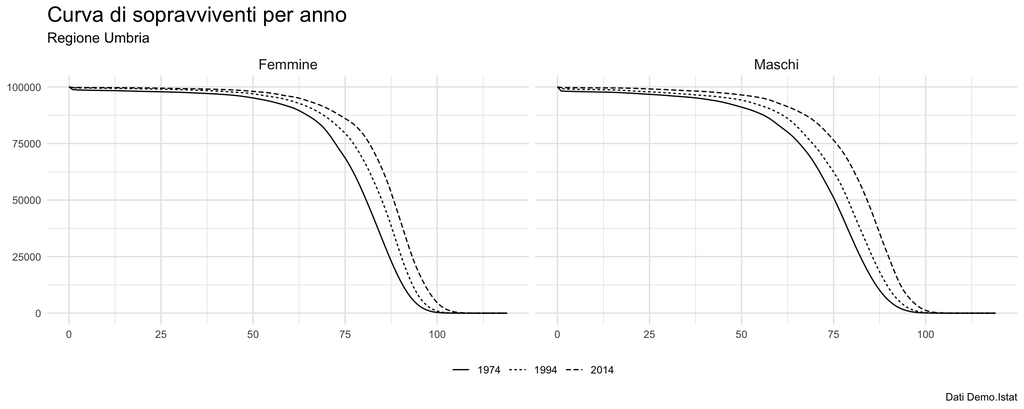

```r
### Umbria ----
umbMort |>
  filter(Sesso != 'Maschi e femmine') |>
  filter(anno == 1974 | anno == 1994 | anno == 2014) |>
  ggplot(aes(x = Età, y = Sopravviventi, linetype = anno, group = anno)) +
  geom_line() +
  facet_wrap(~Sesso) +
  scale_color_manual(values = c('#803014', '#148068')) +
  labs(title = 'Curva di sopravviventi per anno',
       subtitle = 'Regione Umbria',
       caption = 'Dati Demo.Istat') +
  theme(legend.position = 'bottom',
        plot.title = element_text(size = 18),
        plot.subtitle = element_text(size = 12),
        strip.text = element_text(size = 12),
        panel.background = element_blank(),
        panel.grid = element_line(colour = 'gray90'),
        legend.title = element_blank(),
        strip.background = element_blank(),
        axis.ticks = element_blank(),
        axis.title = element_blank())
```

## Referenze

«Demo - Statistiche demografiche». s.d.

ISTAT. 2019. «Dati statistici per il territorio - Regione Umbria». https://www.istat.it/it/files//2020/05/10_Umbria_Scheda_DEF.pdf.